# README for pltimggg

Petar Mimica

11/29/2016

## Prerequisites

You need to install the following packages: ggplot2, reshape2 and RColorBrewer. If you plan to use plotimggg to convolve the arrays, you also need to install spatialfil.

A reminder: to install these packages, you can run the following code:

```r
install.packages("ggplot2")
install.packages("reshape2")
install.packages("RColorBrewer")
install.packages("spatialfil")
```

## 2D plots

### Basic usage

For it to make any sense to use pltimggg, you need to have a 2D array and the corresponding vectors corresponding to each axis. In this example we will generate a 100x100 array with axes spanning the interval [0, 1].

```r
# source (do not forget to use the correct path to pltimggg.R)
source("pltimggg.R")



# define array dimensions
nx <- 100
ny <- 100

# axes limits
xlim = c(0e0, 1e0)
ylim = c(0e0, 1e0)

# compute axes
x <- (0 : (nx - 1)) * (xlim[2] - xlim[1]) / (nx - 1) + xlim[1]
y <- (0 : (ny - 1)) * (ylim[2] - ylim[1]) / (ny - 1) + ylim[1]

# declare array
img <- array(1e0, c(nx, ny))

# fill array with random numbers in a certain interval
img <- 10^(apply(img, c(1, 2), function(x) {rnorm(1, 0.5, 0.3) }) * 2e0) * 1e-15
```

Now we can try to plot the image using the default settings:

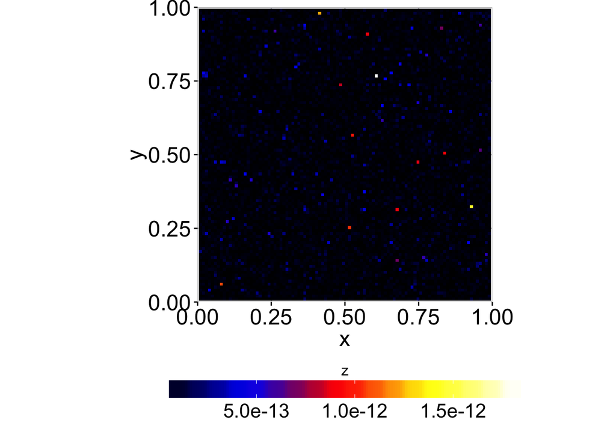

```r
pltimggg.plot2D(x, y, img)
```

### Parameters

Now we review the parameters that can be passed to pltimggg.plot2D.

#### zlog: logarithmic scale for the values, default zlog = FALSE

To plot the image in logarithmic scale set zlog to TRUE:

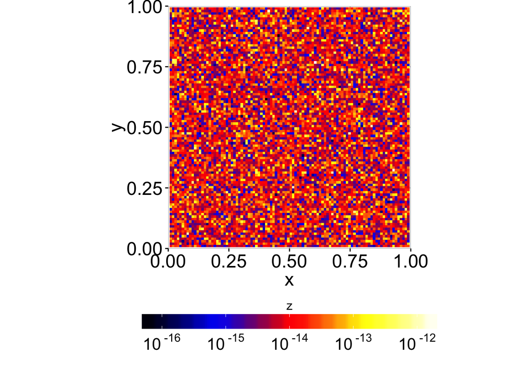

```r
pltimggg.plot2D(x, y, img, zlog=TRUE)
```

#### legend.direction: colourbar direction, default legend.direction = “horizontal”

To plot the colourbar on the right set legend.direction to “vertical”:

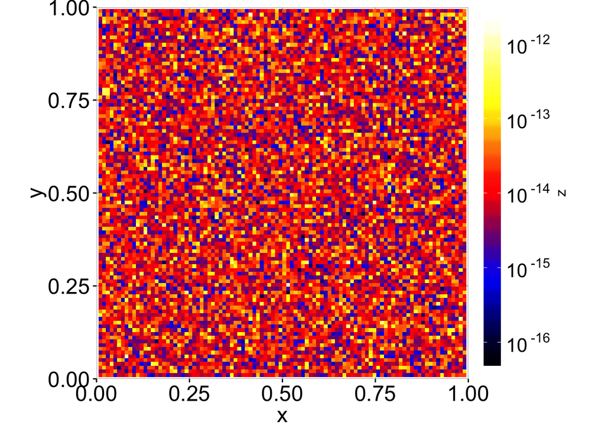

```r
pltimggg.plot2D(x, y, img, zlog=TRUE, legend.direction = "vertical")
```

#### xlab, ylab and zlab: axes and colourbar labels, default: “x”, “y” and “z”, respectively

The labels of the axes and the colourbar can be changed by giving the appropriate values to xlab, ylab and zlab:

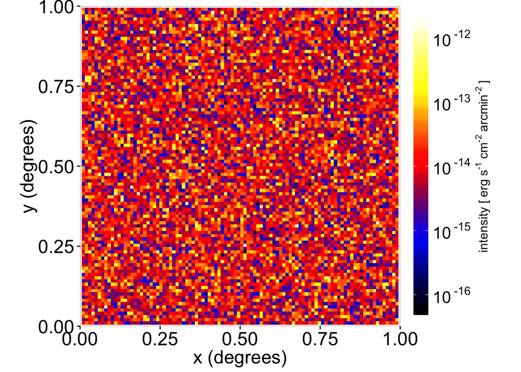

```r
pltimggg.plot2D(x, y, img, zlog=TRUE, legend.direction = "vertical", xlab="x (degrees)", ylab="y (degrees)", zlab=expression(paste("intensity ["~"erg"~"s"^"-1"~"cm"^"-2"~"arcmin"^"-2"~"]")))
```

#### conv.kernel: image convolution

```
## [1] "Convolving with sigma =  0.015  (pixels =  1.485 )"
```

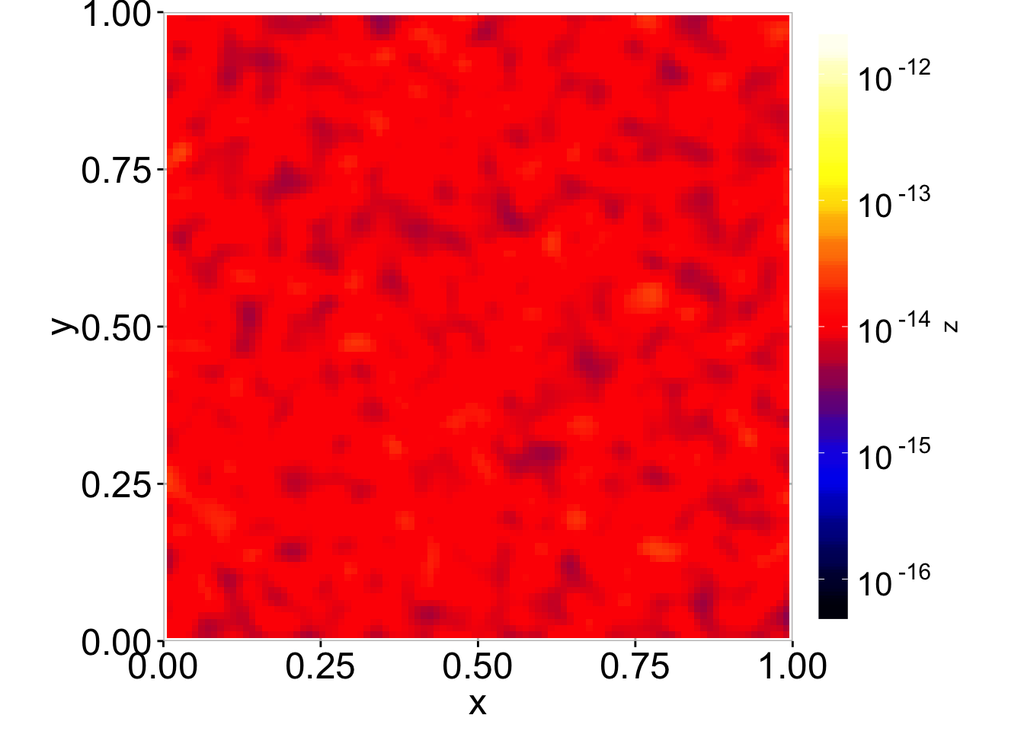

```r
pltimggg.plot2D(x, y, img, zlog=TRUE, legend.direction = "vertical", conv.kernel = 0.015)
```

#### zlinformat: colourscale values format, default zlinformat = FALSE

When the image is plotted in logarithmic scale, by default the colourbar values are printed as powers of ten. If we want them to be printed in the scientific notation we set zlinformat to TRUE:

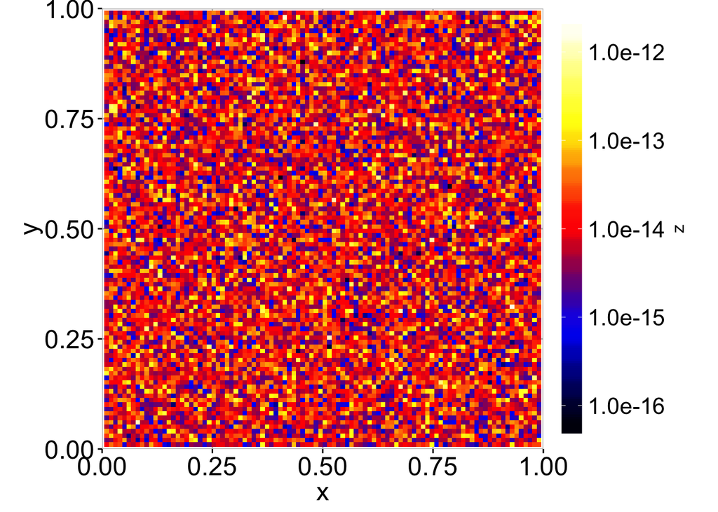

```r
pltimggg.plot2D(x, y, img, zlog=TRUE, legend.direction = "vertical", zlinformat=TRUE)
```

#### zdigits: number of digits in the scientific notation, default zdigits = 1

By default only one digit is printed in the scientific notation. To use 2 set zdigits to 2 (note that this only has an effect when zlinformat = TRUE or when plotting in a linear scale [zlog = FALSE]):

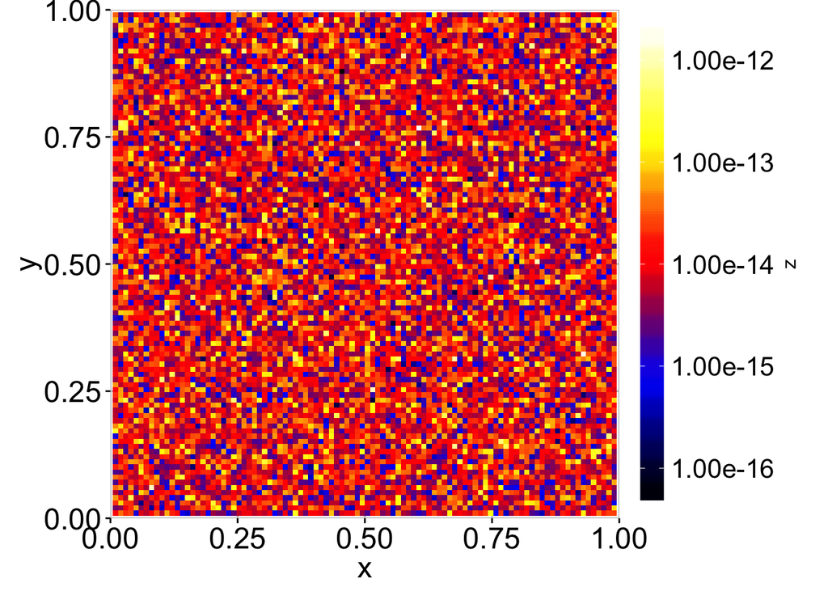

```r
pltimggg.plot2D(x, y, img, zlog=TRUE, legend.direction = "vertical", zlinformat=TRUE, zdigits = 2)
```

The parameter has no effect when the powers of ten are used:

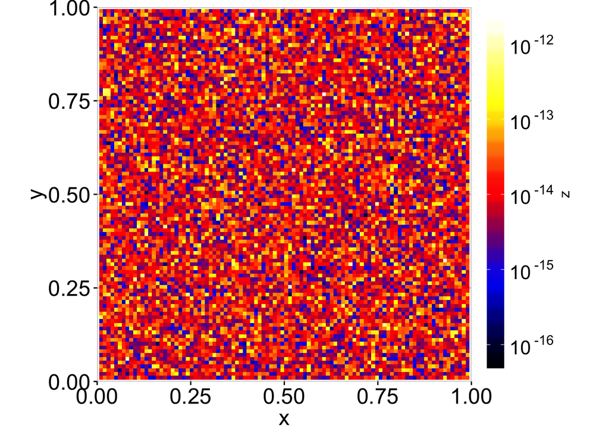

```r
pltimggg.plot2D(x, y, img, zlog=TRUE, legend.direction = "vertical", zdigits = 2)
```

#### zbarwidth and zbarheight: colourbar width and height, default: zbarwidth = 20, zbarheight = 1

By default the colourbar is horizontal, its length is 20 (zbarwidth = 20) and its thickness is 1 (zbarheight = 1). If legend.direction is set to “vertical” these values are interchanged by the routine itself.

To make the horizontal colourbar longer and thicker set zbarwidth to 25 and zbarheight to 2:

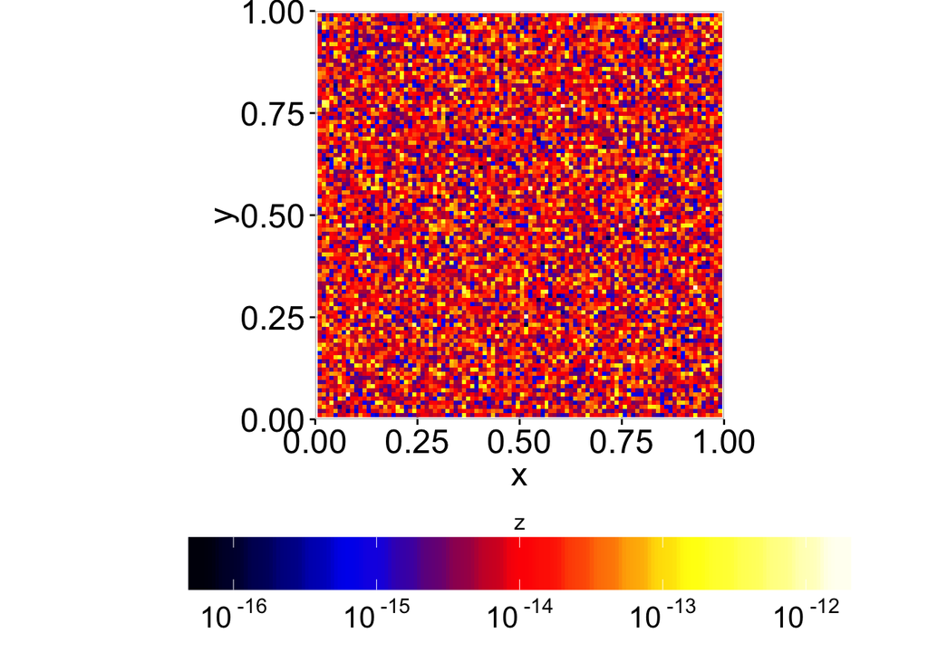

```r
pltimggg.plot2D(x, y, img, zlog=TRUE, zbarwidth=25, zbarheight = 2)
```

For the vertical bar remember that zbarwidth and zbarheight have the opposite meaning than in the horizontal case. To reduce the length and thickness set zbarheight to 18 and zbarwidth to 0.5:

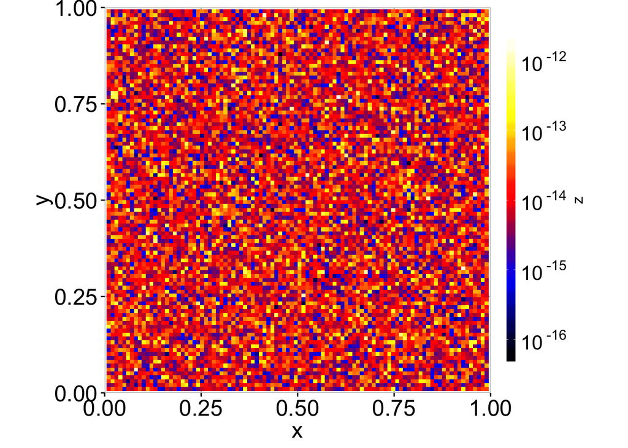

```r
pltimggg.plot2D(x, y, img, zlog=TRUE, legend.direction = "vertical", zbarheight = 18, zbarwidth = 0.5)
```

#### ztitleposition: colourbar title position, default ztitleposition = “top”

By default, the position of the colourbar title is above the colourbar in the horizontal case and to the right in the vertical case. To plot the title below the vertical colourbar set ztitleposition to “bottom”:

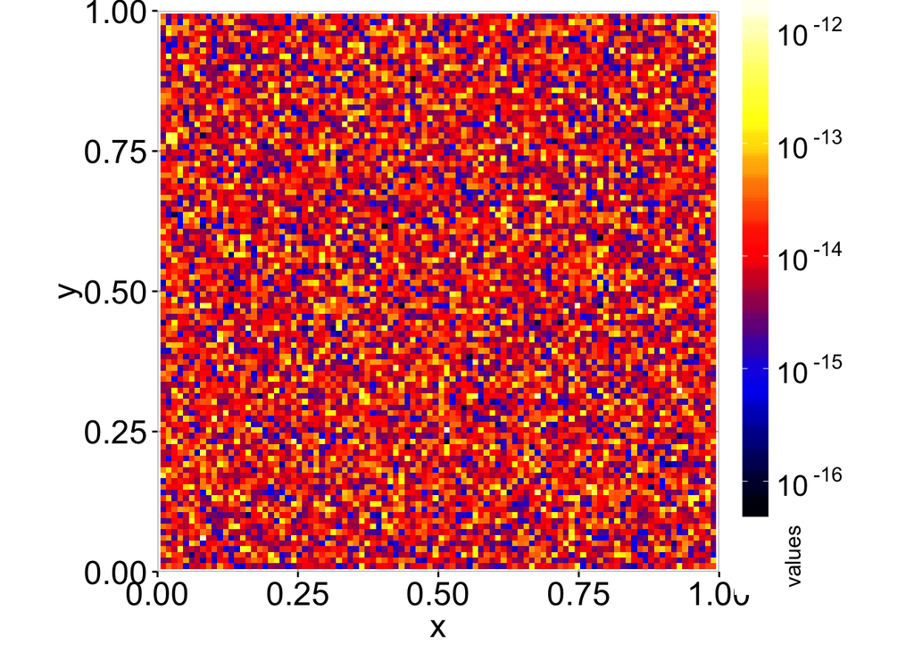

```r
pltimggg.plot2D(x, y, img, zlog=TRUE, legend.direction = "vertical", ztitleposition = "bottom", zlab="values")
```

Note that the title is rotated by 90 degrees, which is not something we may necessarily want here. The next parameter can help.

#### zitleorientation: colourbar title orientation angle, default ztitleorientation = 0

By default, the title is printed horizonally (ztitleorientation = 0) when the colourbar is horizontal, and vertically (ztitleorientation = 90) when it is vertical (this is automatically changed by the routine when legend.direction is set to “vertical”). In the previous example we may want to print the title horizontally and set ztitleorientation to 0:

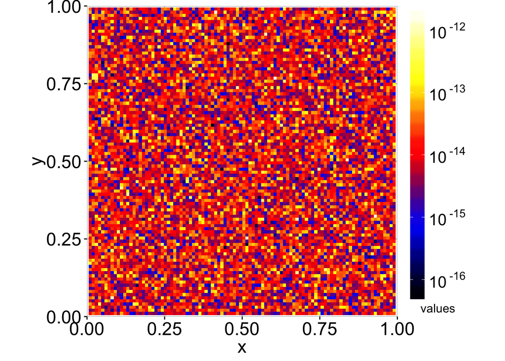

```r
pltimggg.plot2D(x, y, img, zlog=TRUE, legend.direction = "vertical", ztitleposition = "bottom", zlab="values", ztitleorientation = 0)
```

#### ztitlehjust and ztitlevjust: title horizontal and vertical justification, default: 0.5 both

By default, the title is centered both horizontally and vertically (ztitlehjust = 0.5 and ztitlevjust = 0.5). To justify left (top), set the value to 0, and for the right bottm) justification set it to 1.

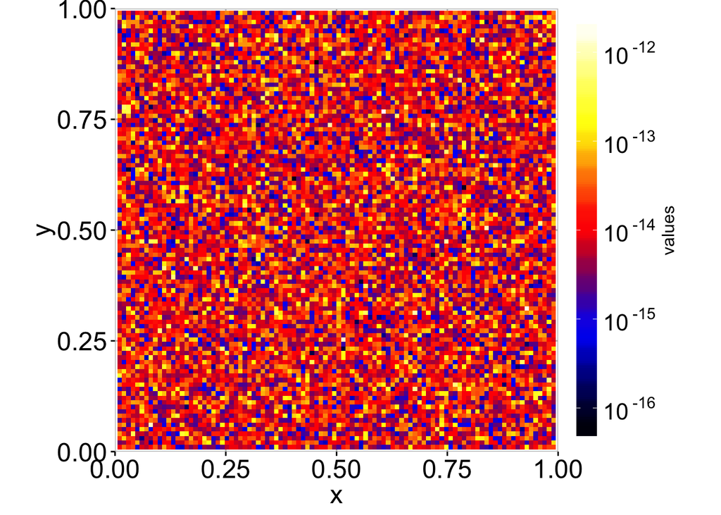

```r
pltimggg.plot2D(x, y, img, zlog=TRUE, legend.direction = "vertical", zlab="values", ztitlevjust = 0)
```

Move the title to the right:

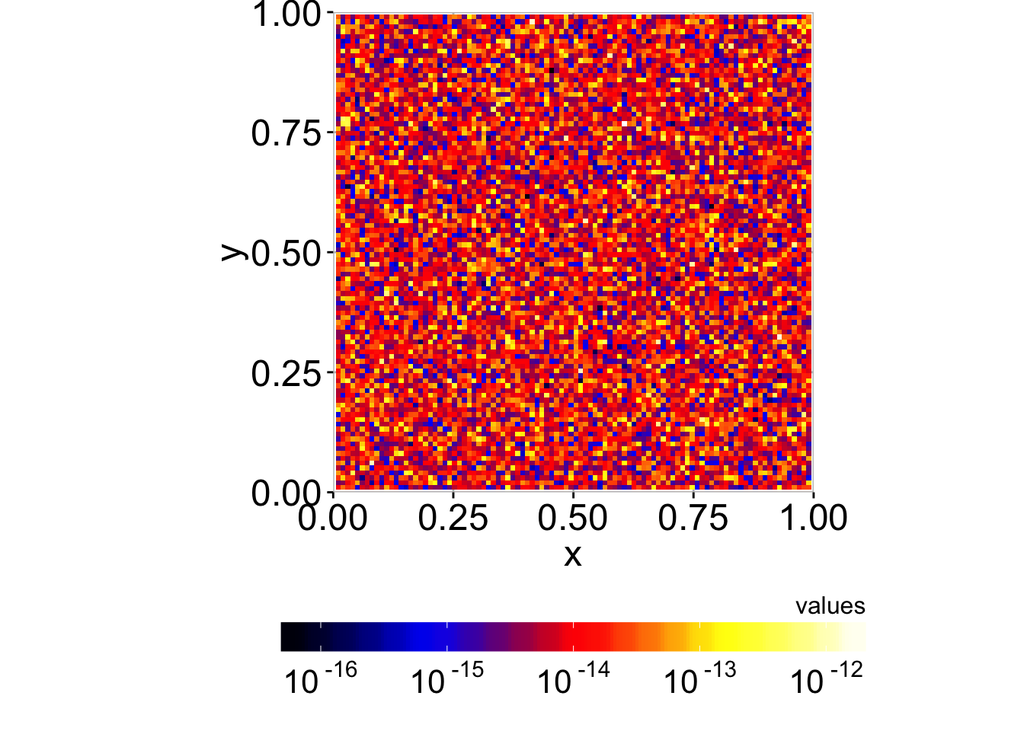

```r
pltimggg.plot2D(x, y, img, zlog=TRUE, zlab="values", ztitlehjust = 1)
```

#### colours: colourscale to be used, default: internally defined rainbow

There is a rainbow colourscale defined internally. You can replace it by your own colourscale. For example, to use grayscale you first generate the colours useing e.g. colorRampPalette and then pass the result to plotimggg.plot2D:

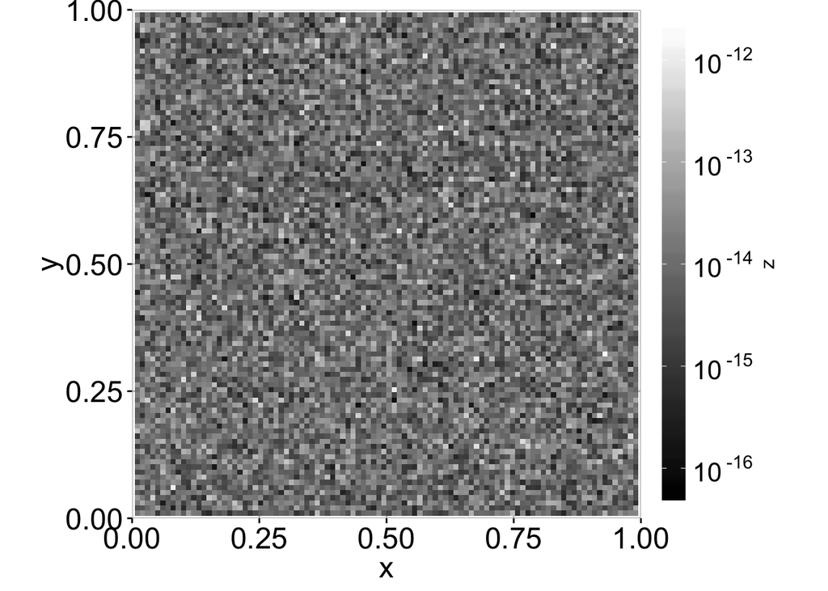

```r
myPalette <- colorRampPalette(c("black", "white"))(100)
pltimggg.plot2D(x, y, img, zlog=TRUE, legend.direction = "vertical", colours = myPalette)
```

You can also combine the palettes. Let’s add another two palettes, usefull when particular ranges of values should be emphasized:

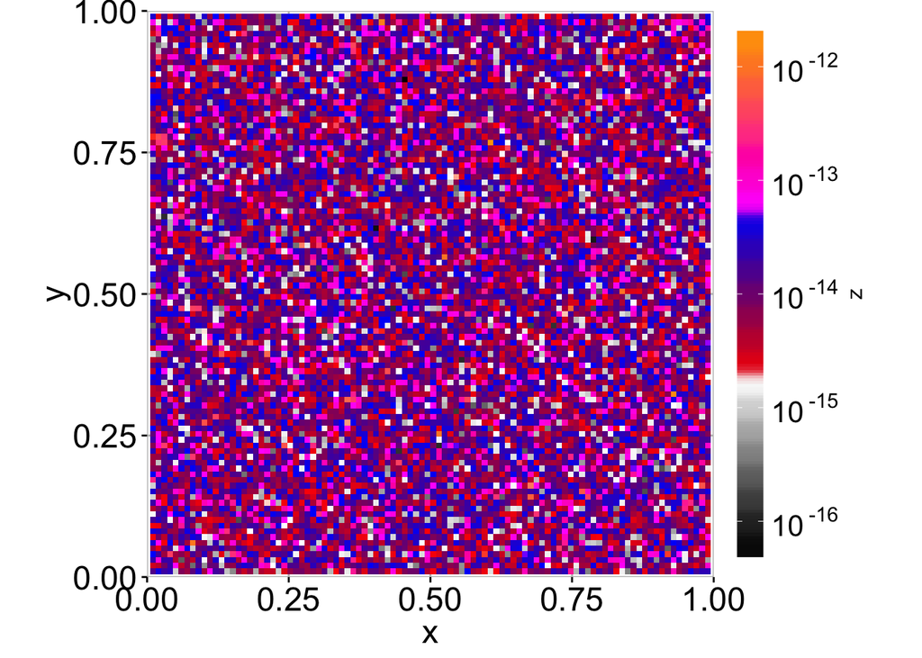

```r
myPalette <- c(colorRampPalette(c("black", "white"))(100), colorRampPalette(c("red", "blue"))(100), colorRampPalette(c("magenta", "orange"))(100))
pltimggg.plot2D(x, y, img, zlog=TRUE, legend.direction = "vertical", colours = myPalette)
```

“Interesting” plots can be generated by shuffling the colours (not the use of rbind() instead of c(), also white has been replaced by green):

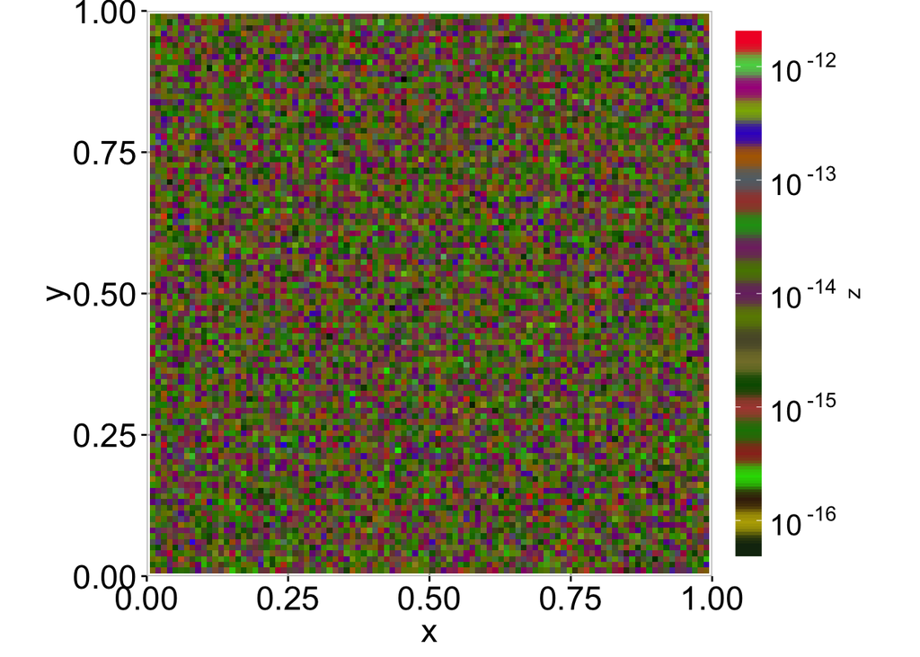

```r
myPalette <- rbind(colorRampPalette(c("black", "green"))(100), colorRampPalette(c("green", "red"))(100), colorRampPalette(c("red", "blue"))(100))
pltimggg.plot2D(x, y, img, zlog=TRUE, legend.direction = "vertical", colours = myPalette)
```

#### theme: ggplot theme to be used, default: internally defined theme

plotimggg.plot2D defines a reasonable black and white theme with some adjustments for fonts. You can supply your own theme instead. For exmple, to use the minimal theme set theme to theme_minimal():

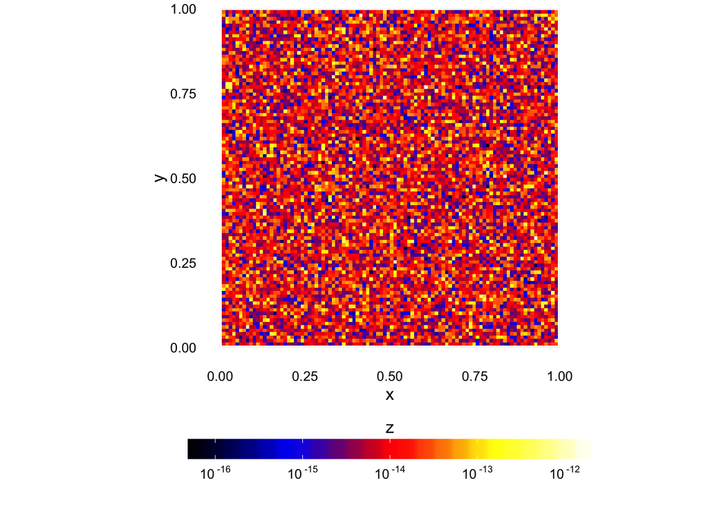

```r
pltimggg.plot2D(x, y, img, zlog=TRUE, theme = theme_minimal())
```

More information can be obtained by reading the ggplot documentation. Or you can copy the definition of “mytheme” from the plotimggg.R and create your own custom theme.